# EDA Diamonds 3

Francia Moscoso

March 20, 2016

setwd(“~/SprintboardProject”)

**Loading Libraries and ‘diamonds’ data set**

```r
library(ggplot2)
library(gridExtra)
library(dplyr)
```

To silence the execution of the library function eg.library(dplyr), use statement: {r message=F, warning=F}

```r
data("diamonds")
str(diamonds)
```

```
Classes 'tbl_df', 'tbl' and 'data.frame':   53940 obs. of  10 variables:
 $ carat  : num  0.23 0.21 0.23 0.29 0.31 0.24 0.24 0.26 0.22 0.23 ...
 $ cut    : Ord.factor w/ 5 levels "Fair"<"Good"<..: 5 4 2 4 2 3 3 3 1 3 ...
 $ color  : Ord.factor w/ 7 levels "D"<"E"<"F"<"G"<..: 2 2 2 6 7 7 6 5 2 5 ...
 $ clarity: Ord.factor w/ 8 levels "I1"<"SI2"<"SI1"<..: 2 3 5 4 2 6 7 3 4 5 ...
 $ depth  : num  61.5 59.8 56.9 62.4 63.3 62.8 62.3 61.9 65.1 59.4 ...
 $ table  : num  55 61 65 58 58 57 57 55 61 61 ...
 $ price  : int  326 326 327 334 335 336 336 337 337 338 ...
 $ x      : num  3.95 3.89 4.05 4.2 4.34 3.94 3.95 4.07 3.87 4 ...
 $ y      : num  3.98 3.84 4.07 4.23 4.35 3.96 3.98 4.11 3.78 4.05 ...
 $ z      : num  2.43 2.31 2.31 2.63 2.75 2.48 2.47 2.53 2.49 2.39 ...
```

**Create a histogram of diamond prices. Facet the histogram by diamond color and use cut to color the histogram bars. The plot should look something like this: http://i.imgur.com/b5xyrOu.jpg** **Note: In the link, a color palette of type ‘qual’ was used to color the histogram using scale_fill_brewer(type = ‘qual’)**

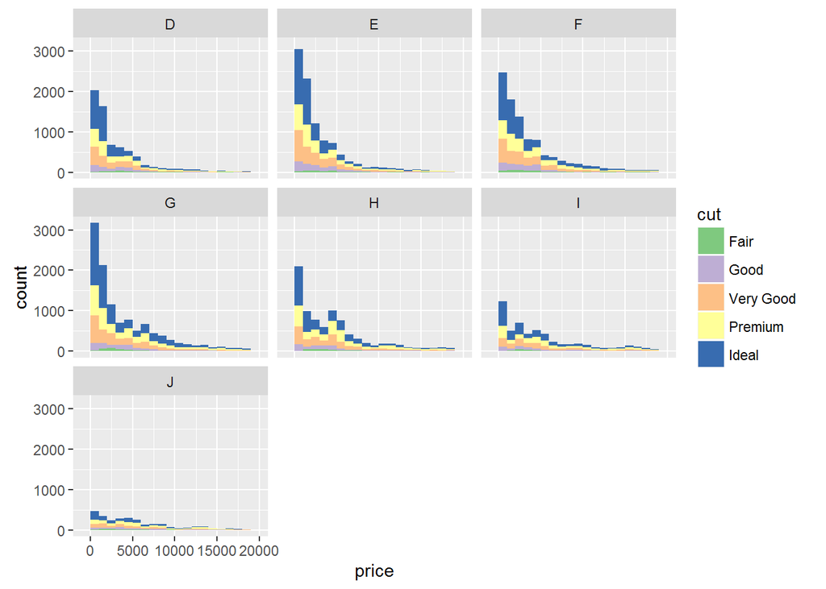

```r
ggplot(diamonds, aes(x = price, fill=cut)) +
geom_histogram(binwidth = 1000) + facet_wrap(~color) + scale_fill_brewer(type="qual")
```

**Create a scatterplot of diamond price vs. table and color the points by the cut of the diamond. The plot should look something like this: http://i.imgur.com/rQF9jQr.jpg. Note: In the link, a color palette of type ‘qual’ was used to color the scatterplot using scale_color_brewer(type = ‘qual’)**

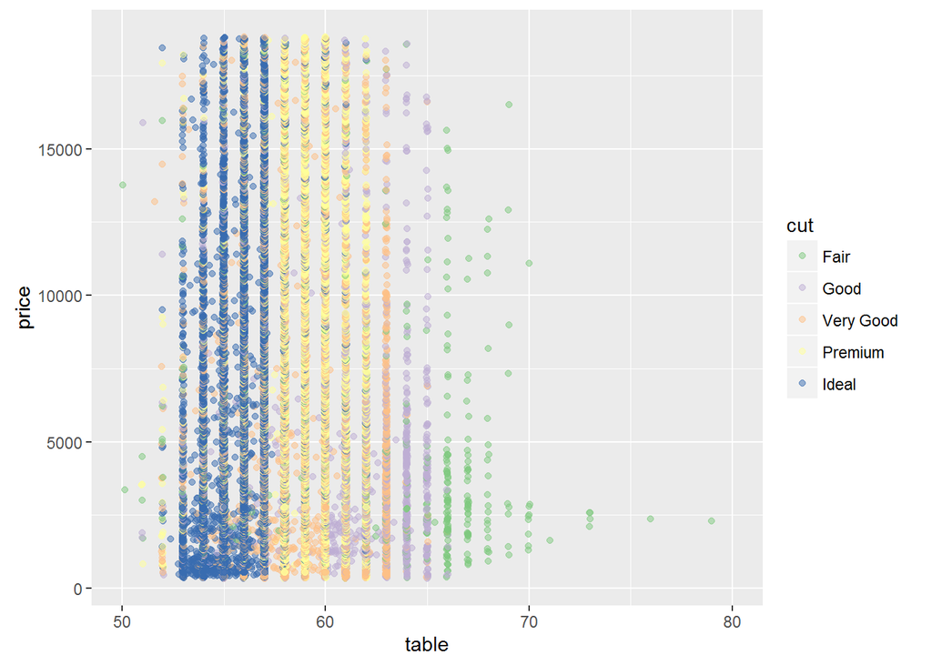

```r
ggplot(diamonds, aes(x=table, y =price, color=cut)) +
       geom_point(alpha=1/2,position="jitter") +
       xlim(50,80) +
       scale_color_brewer(type="qual")
```

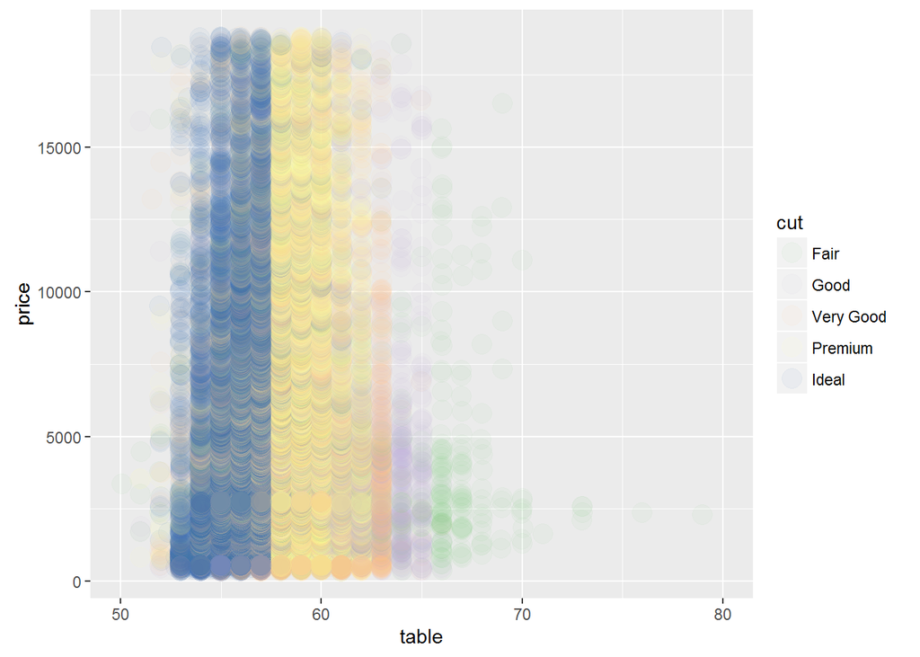

```r
ggplot(diamonds, aes(x=table, y =price, color=cut)) +
       geom_point(alpha=1/20,size = 5, position=position_jitter(h=0)) +
       xlim(50,80) +
       scale_color_brewer(type="qual")
```

This graphic looks much better with alpha=1/2 and size = 2.5 and scale_x_countinuos (eliminate the xlim).

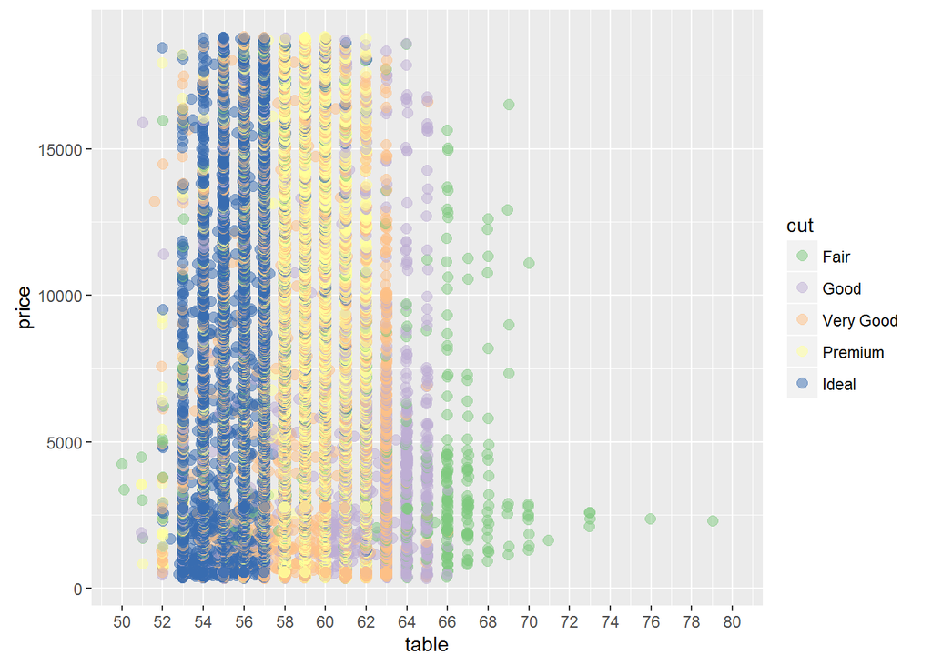

```r
ggplot(diamonds, aes(x=table, y =price, color=cut)) +
       geom_jitter(alpha=1/2,size = 2.5, position=position_jitter(h=0)) +
       scale_x_continuous(breaks = seq(50, 80, by=2), limits = c(50,80)) +
       scale_color_brewer(type="qual")
```

```r
diamonds$volumen <- (diamonds$x*diamonds$y*diamonds$z)
max(diamonds$volumen)
```

```
## [1] 3840.598
```

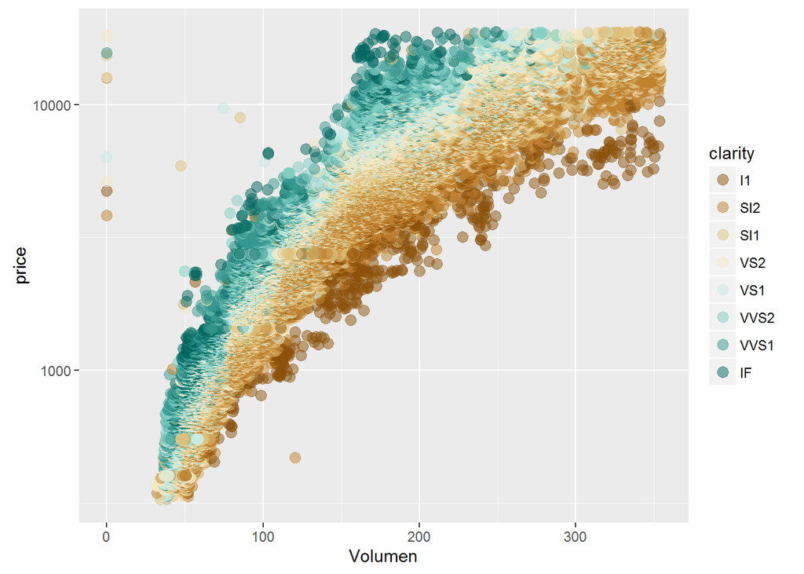

```r
Vol99 <- quantile(diamonds$volumen, probs = 0.99, na.rm = FALSE,type = 7)

ggplot(diamonds, aes(x=(x*y*z), y=price, color=clarity)) +
         scale_y_log10() +
       geom_jitter(alpha=1/2,size = 3, position=position_jitter(h=0)) +
       scale_x_continuous(name="Volumen",breaks = seq(0, Vol99, by=100),
                         limits = c(0,Vol99)) +
       scale_color_brewer(type="div")
```

**Proportion of Friendships Initiated:**  
**Many interesting variables are derived from two or more others. For example, we might wonder how much of a person’s network on a service like Facebook the user actively initiated. Two users with the same degree (or number of friends) might be very different if one initiated most of those connections on the service, while the other initiated very few. So it could be useful to consider this proportion of existing friendships that the user initiated. This might be a good predictor of how active a user is compared with their peers, or other traits, such as personality (i.e., is this person an extrovert?). Your task is to create a new variable called ‘prop_initiated’ in the Pseudo-Facebook data set. The varpf iable should contain the proportion of friendships that the user initiated.**

```r
setwd("~/SprintboardProject")
pf <- read.csv("pseudo_facebook.csv",header=TRUE)
head(pf)
```

```
   userid age dob_day dob_year dob_month gender tenure friend_count
1 2094382  14      19     1999        11   male    266            0
2 1192601  14       2     1999        11 female      6            0
3 2083884  14      16     1999        11   male     13            0
4 1203168  14      25     1999        12 female     93            0
5 1733186  14       4     1999        12   male     82            0
6 1524765  14       1     1999        12   male     15            0
  friendships_initiated likes likes_received mobile_likes
1                     0     0              0            0
2                     0     0              0            0
3                     0     0              0            0
4                     0     0              0            0
5                     0     0              0            0
6                     0     0              0            0
  mobile_likes_received www_likes www_likes_received
1                     0         0                  0
2                     0         0                  0
3                     0         0                  0
4                     0         0                  0
5                     0         0                  0
6                     0         0                  0
```

```r
pf$prop_initiated <- (pf$friendships_initiated/pf$friend_count)
summary(pf$prop_initiated)
```

```
   Min. 1st Qu.  Median    Mean 3rd Qu.    Max.    NA's
 0.0000  0.4524  0.6250  0.6078  0.7838  1.0000    1962
```

**prop_initiated vs. tenure:**  
**Create a line graph of the median proportion of friendships initiated (‘prop_initiated’) vs.tenure and color the line segment by year_joined.bucket.Recall, we created year_joined.bucket in Lesson 5 by first creating year_joined from the variable tenure. Then, we used the cut function on year_joined to create four bins or cohorts of users:**  
**(2004, 2009], (2009, 2011], (2011, 2012], (2012, 2014]**  
**The plot should look something like this http://i.imgur.com/vNjPtDh.jpg OR this http://i.imgur.com/IBN1ufQ.jpg**

Create variable ‘year_joined’:

```r
pf$year_joined <- floor(2014 - pf$tenure/365)
summary(pf$year_joined)
```

```
   Min. 1st Qu.  Median    Mean 3rd Qu.    Max.    NA's
   2005    2012    2012    2012    2013    2014       2
```

table of variable ‘year_joined’

```r
table(pf$year_joined)
```

```
 2005  2006  2007  2008  2009  2010  2011  2012  2013  2014
    9    15   581  1507  4557  5448  9860 33366 43588    70
```

Cut variable year_joined to create 4 bins or buckets of users.

```r
pf$year_joined.bucket <- cut(pf$year_joined,
                        c(2004,2009,2011,2012,2014))
head(pf$year_joined.bucket)
```

```
[1] (2012,2014] (2012,2014] (2012,2014] (2012,2014] (2012,2014] (2012,2014]
Levels: (2004,2009] (2009,2011] (2011,2012] (2012,2014]
```

ggplot tenure vs. prop_initiated.

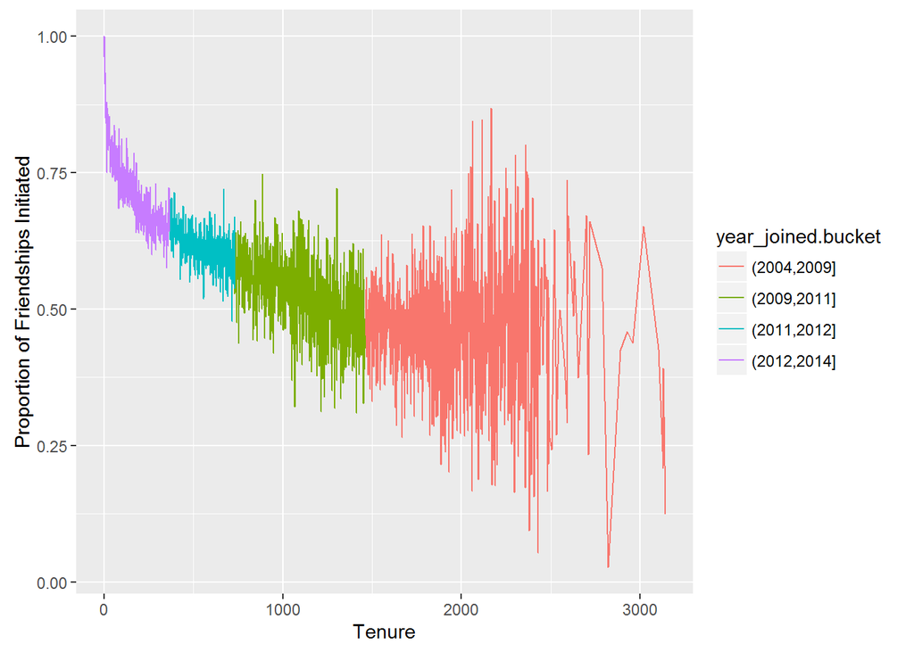

```r
ggplot(aes(x=tenure,y=prop_initiated),data = subset(pf, !is.na(year_joined.bucket))) +
  xlab("Tenure") +
  ylab("Proportion of Friendships Initiated") +
  geom_line(aes(color=year_joined.bucket),stat="summary",fun.y=median)
```

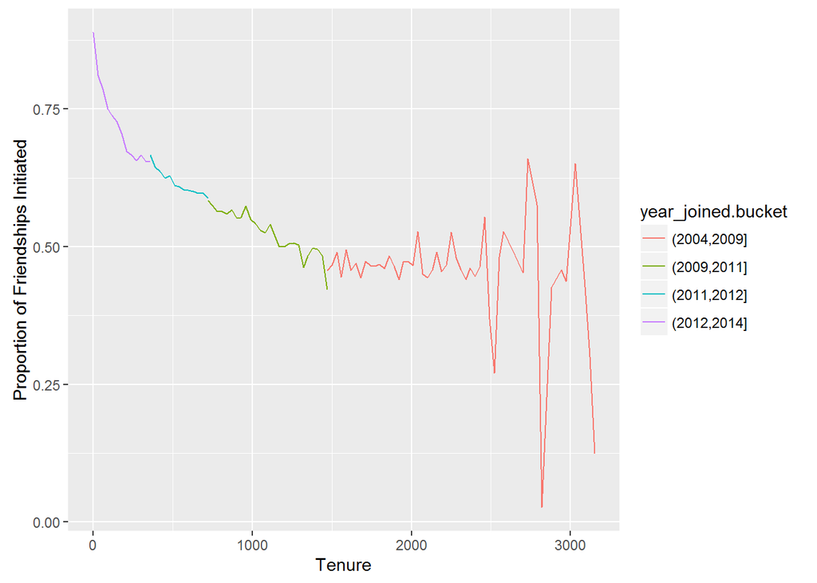

```r
ggplot(aes(x=(30*round(tenure/30)),y=prop_initiated),data = subset(pf, !is.na(year_joined.bucket))) +
  xlab("Tenure") +
  ylab("Proportion of Friendships Initiated") +
  geom_line(aes(color=year_joined.bucket),stat="summary",fun.y=median)
```

Using ‘geom_smooth’ to Smooth graphic.

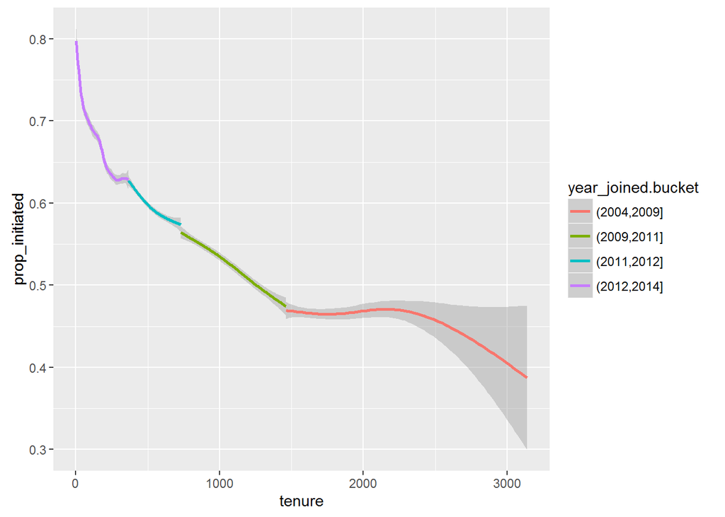

```r
ggplot(aes(x=tenure,y=prop_initiated),data = subset(pf, tenure>=1)) +
  geom_smooth(aes(color=year_joined.bucket))
```

**On average, which group initiated the greaters poportion of its Facebook frienship, the plot with the smoother that you created in the last exercise can help you answer this question**  
People who joined prior to 2009  
People who joined prior to 2009-2011  
People who joined prior to 2011-2012  
People who joined after 2012  
Answer: People who joined after 2012.  
**For the group with the largest proportion of frienship initiated, what is the groups’s average (mean) proportion of friends initiated?**

```r
joined_after_2012 <- pf%>% filter(year_joined > 2012, !is.na(prop_initiated))
mean(joined_after_2012$prop_initiated)
```

```
[1] 0.6653892
```

Another way to see the result is by getting the summary of proportion of friendship by the group of proportion of friends initiated:

```r
by(pf$prop_initiated,pf$year_joined.bucket, summary)
```

```
pf$year_joined.bucket: (2004,2009]
   Min. 1st Qu.  Median    Mean 3rd Qu.    Max.    NA's
 0.0000  0.3418  0.4672  0.4668  0.5910  1.0000       5
--------------------------------------------------------
pf$year_joined.bucket: (2009,2011]
   Min. 1st Qu.  Median    Mean 3rd Qu.    Max.    NA's
 0.0000  0.3924  0.5357  0.5301  0.6750  1.0000      81
--------------------------------------------------------
pf$year_joined.bucket: (2011,2012]
   Min. 1st Qu.  Median    Mean 3rd Qu.    Max.    NA's
 0.0000  0.4576  0.6189  0.5985  0.7619  1.0000     408
--------------------------------------------------------
pf$year_joined.bucket: (2012,2014]
   Min. 1st Qu.  Median    Mean 3rd Qu.    Max.    NA's
 0.0000  0.5115  0.7018  0.6654  0.8490  1.0000    1468
```

Calculating the ‘mean’ using chaning command.

```r
pf%>% filter(year_joined > 2012, !is.na(prop_initiated)) %>% select(prop_initiated)  %>%  summarise(mean (prop_initiated))
```

```
  mean(prop_initiated)
1            0.6653892
```

**Why do you think this group’s proportion of frienship initiated is higher than the others?**  
Perhaps because there was a high number of friends already members in FB when new members joined after 2012 and they initiated the frienship.  
**Create a scatter plot of the price/carat ratio of diamonds. The variable x should be assigned to cut. The points should be colored by diamond color, and the plot should be faceted by clarity. The plot should look something like this http://i.imgur.com/YzbWkHT.jpg.Note: In the link, a color palette of type ‘div’ was used to color the histogram using scale_color_brewer(type = ‘div’)**

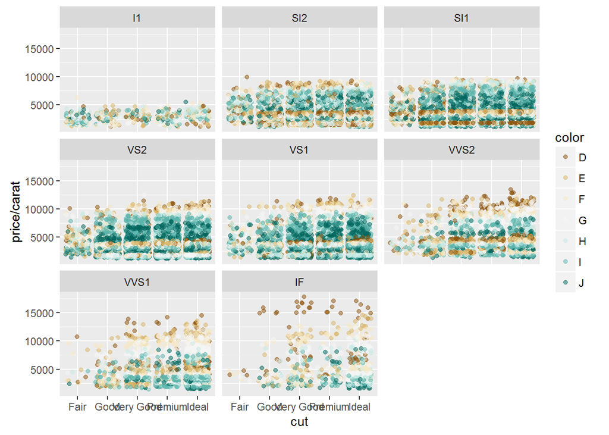

```r
ggplot(diamonds, aes(x=cut, y =price/carat, color=color)) +
       facet_wrap(~clarity) +
       geom_jitter(alpha=1/2, position=position_jitter(h=0)) +
       scale_color_brewer(type="div")
```